# S3 AlturaCovid

## 3. **La relación de la densidad poblacional con la cantidad de fallecidos**

Para este análisis, vemos que hay un dato que tiene unos valores muy alto que corresponde a los habitantes y fallecidos en Lima, por lo que se procederá a remover ese dato para analizar el comportamiento de los demás datos obtenidos.

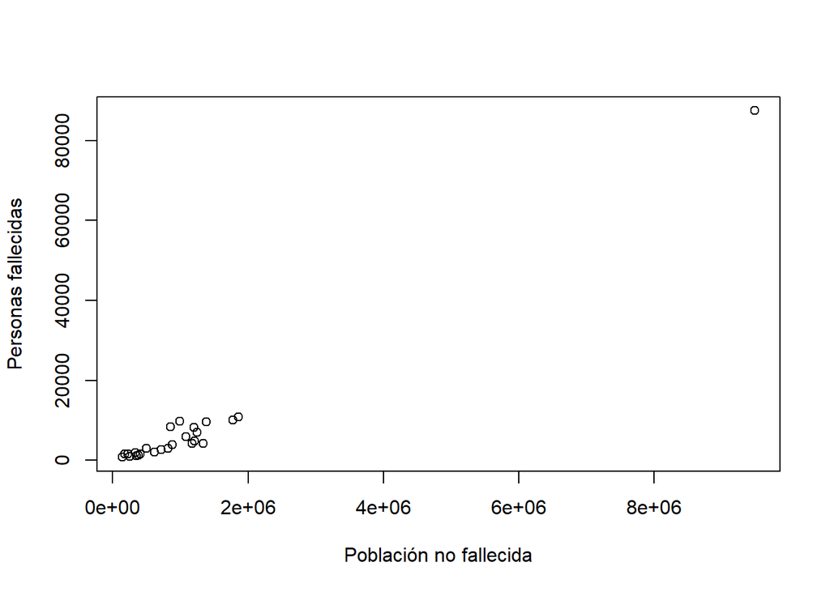

Al remover este dato obtenemos la siguiente gráfica con la cual se procederá a trabajar. La primera gráfica no presenta un modelo lineal en si, mientras que la segunda se presenta la tendencia que presentan estos datos. Además, ante el modelo lineal planteado se verá su compartimiento.

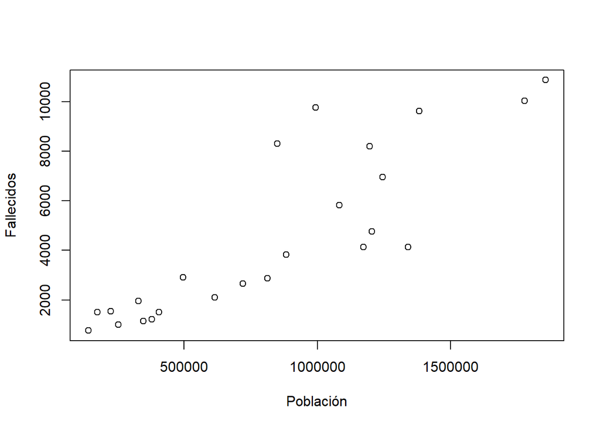

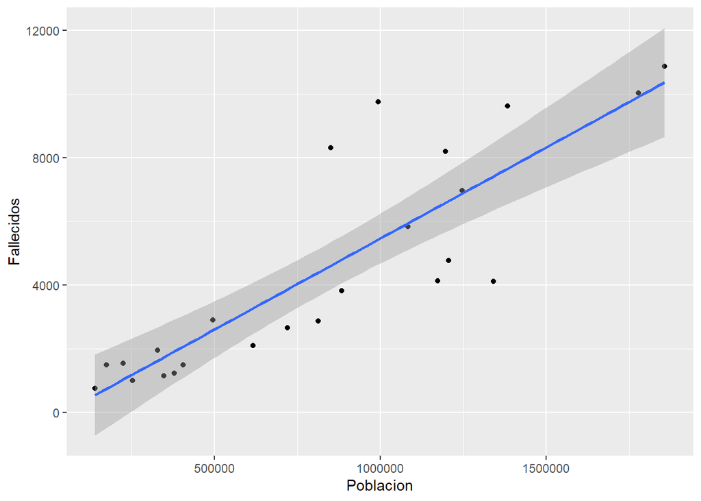

```
##
## Call:
## lm(formula = Fallecidos ~ Poblacion, data = letalidad1)
##
## Residuals:
##     Min      1Q  Median      3Q     Max
## -3288.9 -1015.8    -8.4   507.9  4328.1
##
## Coefficients:
##               Estimate Std. Error t value Pr(>|t|)
## (Intercept) -2.574e+02  6.986e+02  -0.369    0.716
## Poblacion    5.720e-03  7.245e-04   7.895 7.35e-08 ***
## ---
## Signif. codes:  0 '***' 0.001 '**' 0.01 '*' 0.05 '.' 0.1 ' ' 1
##
## Residual standard error: 1748 on 22 degrees of freedom
## Multiple R-squared:  0.7391, Adjusted R-squared:  0.7272
## F-statistic: 62.32 on 1 and 22 DF,  p-value: 7.353e-08
```

Ahora, veremos los gráficos de diagnóstico para el modelo de regresión lineal planteado. Esto nos servirá sobre todo en las predicciones donde tengamos que trabajar con valores particulares. Obtendremos 4 gráficas, las cuales analizaremos una por una:

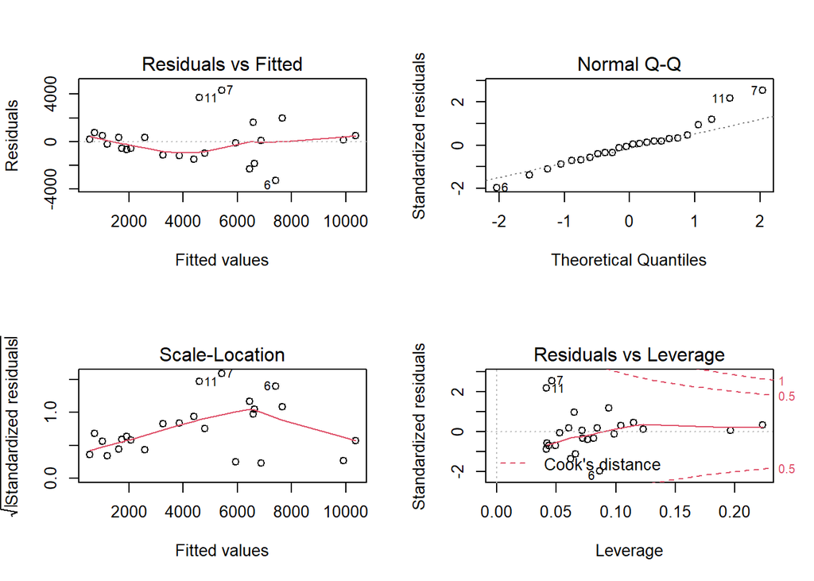

*Normal Q-Q*

Vemos que la mayoría de datos se distribuyen a través de la línea recta lo que indicaría que los residuos están distribuidos de manera normal. Los datos atípicos no se alejan mucho de la recta, por lo que no afectaría a la distribución normal.

*Scale vs Location*

Vemos que el gráfico presenta cierta heterocedasticidad y esto se debe a que nuestro modelo no sigue un modelo lineal de por sí, mas bien, los valores aquí están más dispersos que en los anteriores gráficos. La varianza varía mucho con respecto a los datos.

*Residuos frente a apalancamiento*

## Conclusiones

Tras el análisis del presente informe, podemos concluir que:

1. La base de datos nos logró brindar una perspectiva muy detallada respecto a los casos de fallecimientos por COVID-19 y las variables que nos interesaron investigar, las cuales principalmente fueron edad, números de dosis de vacuna y grado de hospitalización.
2. Se sabe gracias a estudios y el acelerado avance clínico que las vacunas contra el COVID-19 permiten que aquellas personas con las vacunas completas si bien podrían contagiarse del virus, estas evitarían que se desarrollen formas graves de este en el organismo, llegando únicamente a formas leves o asintomáticas de dicha enfermedad. Como pudimos apreciar con nuestra prueba de hipótesis para la hipótesis 5, no encontramos evidencia para rechazar que a lo mucho el 25% de las personas fallecidas a causa de COVID-19 eran personas vacunadas. Además, gracias a su gráfico de distribución de probabilidad normal estándar, pudimos reafirmar que dicha hipótesis se encuentra en la región de aceptación.
3. Consideramos necesario hacer una diferencia entre un análisis de cantidad de fallecidos por región y tasa de letalidad por región. Nos pareció un hallazgo muy importante dado que viéndolo desde un punto de vista de cantidad de fallecidos podemos decir que tenemos una vista más superficial de la situación. Decimos esto porque, especialmente en un país como Perú, saldrán primero las regiones con mayor densidad poblacional, relegando atrás regiones donde, a través de una perspectiva de tasa de letalidad, estas posiblemente estén en una situación igual o peor, debido a que hay una mayor tasa de muertos, tomando en cuenta su población actual.
4. La cantidad de fallecidos y su grado de hospitalización tiene una fuerte relación con la edad que posee la persona con COVID, pues el estudio muestra que la mayor cantidad de personas fallecidas hospitalizadas son personas adultas mayores que estuvieron en unidad de cuidados intensivos (UCI) con una edad en promedio de 65 años. Esto tendría relación con lo que se viene diciendo por parte de la Organización Mundial de la Salud respecto a que los adultos mayores son los más propensos a fallecer por COVID-19.
5. Respecto a las vacunas, logramos demostrar que entre toda la población de fallecidos, las personas vacunadas conforman una parte muy pequeña del universo de personas fallecidas. Incluso conforman un grupo más pequeño aún si es que nos fijamos en el grado de hospitalización más grave, el cual involucra que una persona haya tenido que estar en UCI, requerir oxígeno y ventilación. Esto habla bastante bien de la efectividad de las vacunas y su potencial de reducir el impacto que tiene el COVID en una persona, especialmente en las que se encuentran en los grupos de riesgo.
6. Todas las distintas etapas del proyecto fueron fundamentales para lograr desempeñar la mejor investigación de los datos. Comenzando con la estadística descriptiva, que nos permitió observar de manera rápida y resumida cómo se comportan los datos hasta el momento. Esta etapa fue bastante importante para entender cómo se comportaban los fallecidos por COVID-19, de acuerdo a su edad. Por su parte, la estadística de probabilidades nos fue de ayuda para experimentar y observar aparentes relaciones entre variables que sospechábamos tenían cierto comportamiento entre sí. Esta parte nos sirvió mucho para responder las preguntas que nos realizamos previa a la investigación. Por último, si bien nuestra base de datos puede constituir como una población y no una muestra, la estadística inferencial nos sirvió para comprobar las hipótesis y preguntas que nos realizamos durante la investigación presente, las cuales fueron fundamentales para lograr los objetivos que nos planteamos.

## Bibliografia

- Plataforma Nacional de Datos Abiertos (p. RENIEC). (2020). Calle Schell 310, Miraflores 15074: Secretaría de Gobierno Digital Presidencia del Consejo de Ministros. https://www.datosabiertos.gob.pe/dataset/hospitalizados-vacunados-y-fallecidos-por-covid-19
- Ministerio de Salud. (2020). Centro Nacional de Epidemiología, Prevención y Control de Enfermedades (p. RENIEC). Calle Schell 310, Miraflores 15074: Secretaría de Gobierno Digital Presidencia del Consejo de Ministros. https://www.dge.gob.pe/portalnuevo/covid-19/situacion-del-covid-19-en-el-peru/